# Assignment 03 - Solutions

Statistical Computing and Empirical Methods

## A word of advice

Think of the SCEM labs as going to the gym: if you pay a gym membership, but instead of working out you use a machine to lift the weights for you, you won’t get the benefits.

ChatGPT, DeepSeek, Claude and other GenAI tools can provide answers to most of the questions below. Before you try that, please consider the following: answering the specific questions below is not the point of this assignment. Instead, the questions are designed to give you the chance to develop a better understanding of estimation concepts and a certain level of **statistical thinking**. These are essential skills for any data scientist, even if they end up using generative AI - to write an effective prompt and to catch the common (often subtle) errors that AI produces when trying to solve anything non-trivial.

A very important part of this learning involves not having the answers ready-made for you, but instead taking the time to actually search for the answer, trying something, getting it wrong, and trying again.

So, make the best use of this session. The assignments are not marked, so it is much better to try the yourself even if you get incorrect answers (you’ll be able to correct yourself later when you receive feedback) than to submit a perfect, but GPT’d solution.

## IMPORTANT NOTES:

- **DO NOT** change the code block names. Enter your solutions to each question into the predefined code blocks.
- **DO NOT** add calls to `install.packages()` into your solutions. Some questions may require you to load packages using `library()`. Please do not use any other packages except the ones explicitly listed in the “setup” code block below.

## Part I: Point estimation of parameters

### Q1. Simulating data and estimating the mean

```r
## Question 1.a
set.seed(MY_STUDENT_ID) # <--- Don't change this


# Random uniform distribution
xunif = runif(n=12, min=50, max=80)

xunif.mean = mean(xunif)  # mean
xunif.var  = var(xunif)  # variance

print(xunif.mean)  # printing mean
```

```
## [1] 69.92874
```

```r
print(xunif.var)  # printing variance
```

```
## [1] 58.59786
```

```r
## Question 1.b
set.seed(MY_STUDENT_ID) # <--- Don't change this

# 200 times generating either 0 or 1 where chance of 1 is 25%
rbern = rbinom(n=200, size = 1, prob = 0.25)
print(rbern)
```

```
##   [1] 0 1 1 0 0 0 0 1 0 1 0 0 1 0 0 0 0 0 0 1 1 0 1 0 1 0 0 1 0 0 0 0 0 0 0
##  [36] 0 1 0 1 0 1 0 0 1 1 0 0 0 0 0 1 1 0 1 0 0 1 1 1 0 0 0 0 0 1 0 0 0 0 1
##  [71] 0 0 0 0 0 0 1 0 0 1 0 1 0 0 0 0 0 1 1 0 0 1 0 0 1 0 0 0 0 0 0 0 1 0 1
## [106] 0 0 0 1 0 0 0 0 0 1 0 0 0 0 0 0 0 0 0 1 1 0 0 1 0 0 0 0 0 0 0 0 0 0 0
## [141] 0 0 1 1 0 0 0 0 0 0 1 1 1 0 1 0 0 0 0 1 0 0 0 0 0 0 0 0 0 0 1 0 0 0 1
## [176] 0 0 0 0 0 0 0 0 0 1 1 1 0 0 0 0 0 0 0 0 0 0 1 0 1
```

```r
rbern.p = mean(rbern)  # the mean of the 200 samples
print(rbern.p)  # is 0.255, close to p 0.25
```

```
## [1] 0.255
```

### Q2. Sampling distribution of the mean

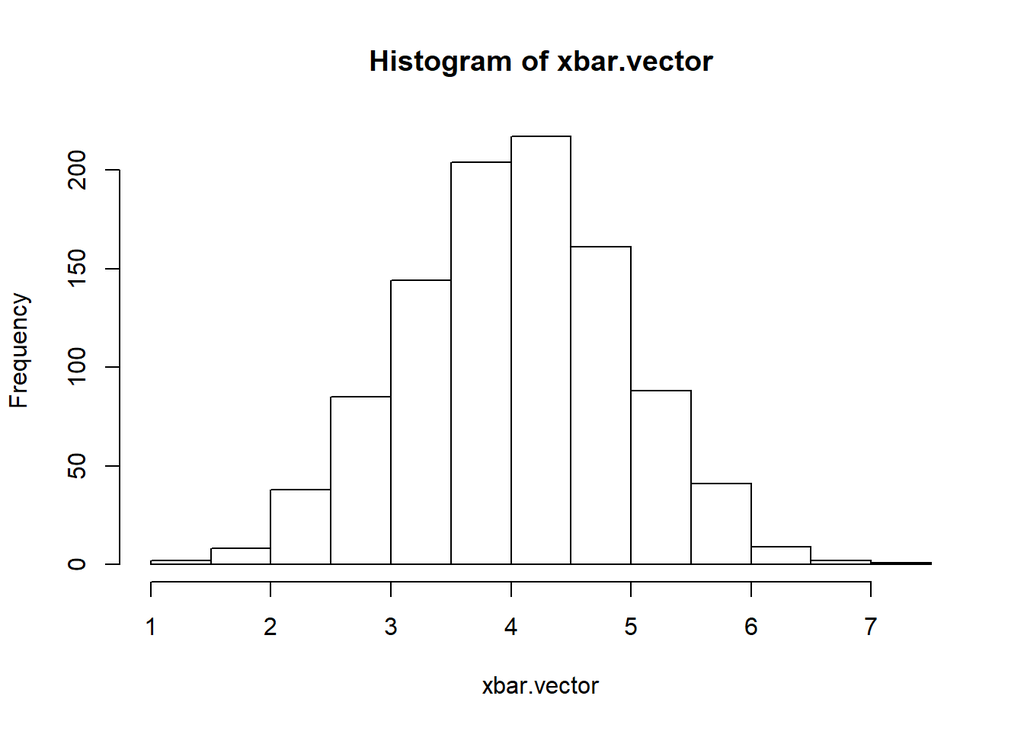

```r
## Question 2.a
set.seed(MY_STUDENT_ID) # <--- Don't change this

# Creating a normal distibution 1000 times and storing its mean every time
xbar.vector = replicate(1000, mean(rnorm(5, mean = 4, sd = 2)))
hist(xbar.vector)
```

```r
## Question 2.b
set.seed(MY_STUDENT_ID) # <--- Don't change this

xbar.mean = mean(xbar.vector)  # mean of the means of 1000 normal distributions
xbar.sd = sd(xbar.vector)  # standard deviation of mean of 1000 normal distributions

print(xbar.mean)
```

```
## [1] 4.032911
```

```r
print(xbar.sd)
```

```
## [1] 0.9055943
```

```r
# Standard Error
print(2/sqrt(5))
```

```
## [1] 0.8944272
```